# Assignment 10

```r
p_and_p_sentences$sentence[2]
```

```
## [1] "by jane austen"
```

```r
austen_chapters <- austen_books() %>%
  group_by(book) %>%
  unnest_tokens(chapter, text, token = "regex",
                pattern = "Chapter|CHAPTER [\\dIVXLC]") %>%
  ungroup()

head(austen_chapters)
```

```
## # A tibble: 6 × 2
##   book                chapter
##   <fct>               <chr>
## 1 Sense & Sensibility "sense and sensibility\n\nby jane austen\n\n(1811)\n\n\n\…
## 2 Sense & Sensibility "\n\n\nthe family of dashwood had long been settled in su…
## 3 Sense & Sensibility "\n\n\nmrs. john dashwood now installed herself mistress …
## 4 Sense & Sensibility "\n\n\nmrs. dashwood remained at norland several months; …
## 5 Sense & Sensibility "\n\n\n\"what a pity it is, elinor,\" said marianne, \"th…
## 6 Sense & Sensibility "\n\n\nno sooner was her answer dispatched, than mrs. das…
```

```r
austen_chapters %>%
  group_by(book) %>%
  summarise(chapters = n())
```

```
## # A tibble: 6 × 2
##   book                chapters
##   <fct>                  <int>
## 1 Sense & Sensibility       51
## 2 Pride & Prejudice         62
## 3 Mansfield Park            49
## 4 Emma                      56
## 5 Northanger Abbey          32
## 6 Persuasion                25
```

```r
head(austen_chapters)
```

```
## # A tibble: 6 × 2
##   book                chapter
##   <fct>               <chr>
## 1 Sense & Sensibility "sense and sensibility\n\nby jane austen\n\n(1811)\n\n\n\…
## 2 Sense & Sensibility "\n\n\nthe family of dashwood had long been settled in su…
## 3 Sense & Sensibility "\n\n\nmrs. john dashwood now installed herself mistress …
## 4 Sense & Sensibility "\n\n\nmrs. dashwood remained at norland several months; …
## 5 Sense & Sensibility "\n\n\n\"what a pity it is, elinor,\" said marianne, \"th…
## 6 Sense & Sensibility "\n\n\nno sooner was her answer dispatched, than mrs. das…
```

```r
bingnegative <- get_sentiments("bing") %>%
  filter(sentiment == "negative")
head(bingnegative)
```

```
## # A tibble: 6 × 2
##   word       sentiment
##   <chr>      <chr>
## 1 2-faces    negative
## 2 abnormal   negative
## 3 abolish    negative
## 4 abominable negative
## 5 abominably negative
## 6 abominate  negative
```

```r
wordcounts <- tidy_books %>%
  group_by(book, chapter) %>%
  summarize(words = n())
head(wordcounts)
```

```
## # A tibble: 6 × 3
## # Groups:   book [1]
##   book                chapter words
##   <fct>                 <int> <int>
## 1 Sense & Sensibility       0     7
## 2 Sense & Sensibility       1  1571
## 3 Sense & Sensibility       2  1970
## 4 Sense & Sensibility       3  1538
## 5 Sense & Sensibility       4  1952
## 6 Sense & Sensibility       5  1030
```

```r
tidy_books %>%
  semi_join(bingnegative) %>%
  group_by(book, chapter) %>%
  summarize(negativewords = n()) %>%
  left_join(wordcounts, by = c("book", "chapter")) %>%
  mutate(ratio = negativewords/words) %>%
  filter(chapter != 0) %>%
  slice_max(ratio, n = 1) %>%
  ungroup()
```

```
## # A tibble: 6 × 5
##   book                chapter negativewords words  ratio
##   <fct>                 <int>         <int> <int>  <dbl>
## 1 Sense & Sensibility      43           161  3405 0.0473
## 2 Pride & Prejudice        34           111  2104 0.0528
## 3 Mansfield Park           46           173  3685 0.0469
## 4 Emma                     15           151  3340 0.0452
## 5 Northanger Abbey         21           149  2982 0.0500
## 6 Persuasion                4            62  1807 0.0343
```

```r
head(tidy_books)
```

```
## # A tibble: 6 × 4
##   book                linenumber chapter word
##   <fct>                    <int>   <int> <chr>
## 1 Sense & Sensibility          1       0 sense
## 2 Sense & Sensibility          1       0 and
## 3 Sense & Sensibility          1       0 sensibility
## 4 Sense & Sensibility          3       0 by
## 5 Sense & Sensibility          3       0 jane
## 6 Sense & Sensibility          3       0 austen
```

Now, let’s use the gutenbergr library to analyze another book, “Moby Dick” by Herman Melville using similar approach.

```r
library(gutenbergr)

moby_dick <- gutenberg_download(2701, mirror = "http://www.gutenberg.lib.md.us/")
head(moby_dick)
```

```
## # A tibble: 6 × 2
##   gutenberg_id text
##          <int> <chr>
## 1         2701 "MOBY-DICK;"
## 2         2701 ""
## 3         2701 "or, THE WHALE."
## 4         2701 ""
## 5         2701 "By Herman Melville"
## 6         2701 ""
```

```r
tidy_moby_dick <- moby_dick %>%
  mutate(text = str_replace_all(text, "[^[:alnum:][:space:]]", "")) %>%
  unnest_tokens(word, text)
head(tidy_moby_dick)
```

```
## # A tibble: 6 × 2
##   gutenberg_id word
##          <int> <chr>
## 1         2701 mobydick
## 2         2701 or
## 3         2701 the
## 4         2701 whale
## 5         2701 by
## 6         2701 herman
```

```r
# Perform sentiment analysis:
# Using NRC lexicon for joy words
nrc_joy <- get_sentiments("nrc") %>%
  filter(sentiment == "joy")

tidy_moby_dick %>%
  inner_join(nrc_joy) %>%
  count(word, sort = TRUE)
```

```
## # A tibble: 409 × 2
##    word        n
##    <chr>   <int>
##  1 good      195
##  2 god       118
##  3 found     115
##  4 true       85
##  5 sun        83
##  6 present    79
##  7 green      48
##  8 mighty     47
##  9 art        41
## 10 hope       34
## # ℹ 399 more rows
```

```r
moby_dick_sentiment <- tidy_moby_dick %>%
  inner_join(get_sentiments("bing")) %>%
  count(index = row_number() %/% 80, sentiment) %>%
  pivot_wider(names_from = sentiment, values_from = n, values_fill = 0) %>%
  mutate(sentiment = positive - negative)
head(moby_dick_sentiment)
```

```
## # A tibble: 6 × 4
##   index negative positive sentiment
##   <dbl>    <int>    <int>     <int>
## 1     0       43       36        -7
## 2     1       40       40         0
## 3     2       40       40         0
## 4     3       28       52        24
## 5     4       48       32       -16
## 6     5       49       31       -18
```

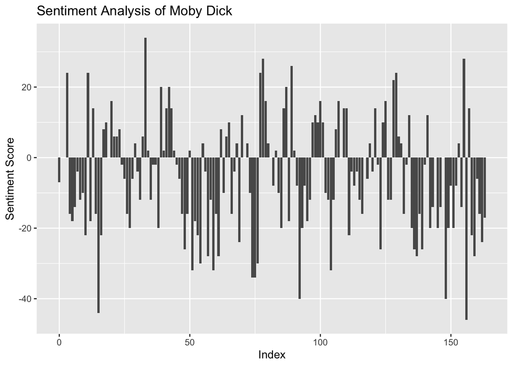

```r
ggplot(moby_dick_sentiment, aes(index, sentiment)) +
  geom_col(show.legend = FALSE) +
  labs(title = "Sentiment Analysis of Moby Dick",
       x = "Index",
       y = "Sentiment Score")
```

```r
# Compare sentiment dictionaries:

# AFINN lexicon
afinn <- tidy_moby_dick %>%
  inner_join(get_sentiments("afinn")) %>%
  group_by(index = row_number() %/% 80) %>%
  summarise(sentiment = sum(value)) %>%
  mutate(method = "AFINN")
# Bing and NRC lexicons
bing_and_nrc <- bind_rows(
  tidy_moby_dick %>%
    inner_join(get_sentiments("bing")) %>%
    mutate(method = "Bing et al."),
  tidy_moby_dick %>%
    inner_join(get_sentiments("nrc") %>%
                 filter(sentiment %in% c("positive", "negative"))) %>%
    mutate(method = "NRC")) %>%
  count(method, index = row_number() %/% 80, sentiment) %>%
  pivot_wider(names_from = sentiment, values_from = n, values_fill = 0) %>%
  mutate(sentiment = positive - negative)
```

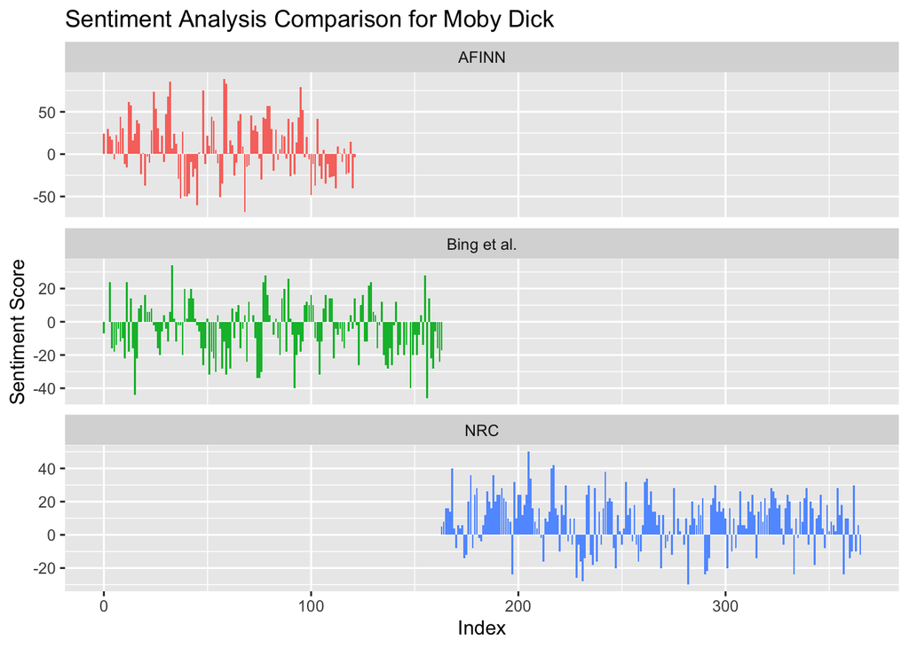

```r
bind_rows(afinn, bing_and_nrc) %>%
  ggplot(aes(index, sentiment, fill = method)) +
  geom_col(show.legend = FALSE) +
  facet_wrap(~method, ncol = 1, scales = "free_y") +
  labs(title = "Sentiment Analysis Comparison for Moby Dick",
       x = "Index",
       y = "Sentiment Score")
```

Now, Let’s use the sentimentr package to perform sentiment analysis on “Moby Dick”:

```r
library(sentimentr)

library(gutenbergr)
moby_dick <- gutenberg_download(2701, mirror = "http://www.gutenberg.lib.md.us/")
head(moby_dick)
```

```
## # A tibble: 6 × 2
##   gutenberg_id text
##          <int> <chr>
## 1         2701 "MOBY-DICK;"
## 2         2701 ""
## 3         2701 "or, THE WHALE."
## 4         2701 ""
## 5         2701 "By Herman Melville"
## 6         2701 ""
```

```r
# prepare the text data:
tidy_moby_dick <- moby_dick %>%
  mutate(text = str_replace_all(text, "[^[:alnum:][:space:]]", "")) %>%
  unnest_tokens(sentence, text, token = "sentences")
head(tidy_moby_dick)
```

```
## # A tibble: 6 × 2
##   gutenberg_id sentence
##          <int> <chr>
## 1         2701 mobydick
## 2         2701 or the whale
## 3         2701 by herman melville
## 4         2701 contents
## 5         2701 etymology
## 6         2701 extracts supplied by a subsublibrarian
```

```r
# perform sentiment analysis using sentimentr:

# calculate sentiment for each sentence
sentiment_scores <- sentiment(tidy_moby_dick$sentence)
# add sentiment scores to the original data
tidy_moby_dick <- tidy_moby_dick %>%
  mutate(sentiment = sentiment_scores$sentiment)
head(tidy_moby_dick)
```

```
## # A tibble: 6 × 3
##   gutenberg_id sentence                               sentiment
##          <int> <chr>                                      <dbl>
## 1         2701 mobydick                                       0
## 2         2701 or the whale                                   0
## 3         2701 by herman melville                             0
## 4         2701 contents                                       0
## 5         2701 etymology                                      0
## 6         2701 extracts supplied by a subsublibrarian         0
```

```r
# aggregate sentiment scores by index
moby_dick_sentiment <- tidy_moby_dick %>%
  mutate(index = row_number() %/% 80) %>%
  group_by(index) %>%
  summarise(sentiment = sum(sentiment))
head(moby_dick_sentiment)
```

```
## # A tibble: 6 × 2
##   index sentiment
##   <dbl>     <dbl>
## 1     0     0.287
## 2     1     1.24
## 3     2    -0.424
## 4     3     0.223
## 5     4     0.201
## 6     5    -1.25
```

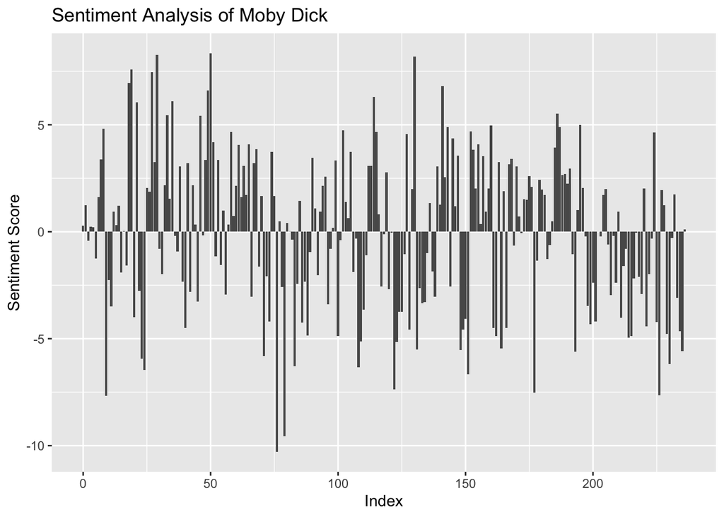

```r
ggplot(moby_dick_sentiment, aes(index, sentiment)) +
  geom_col(show.legend = FALSE) +
  labs(title = "Sentiment Analysis of Moby Dick",
       x = "Index",
       y = "Sentiment Score")
```

Conclusion:

This follwing graph shows the emotional ups and downs in Moby Dick:

- Big Swings: The emotions change a lot, with some parts feeling positive and others negative, creating a rollercoaster of feelings.
- Mostly Negative: There are more dips into negative emotions, which makes sense since Moby Dick is a story with dark themes, like revenge and obsession.
- Some Calm Sections: Many points are close to zero, which might be more neutral parts of the story where things aren’t very emotional.
- Positive Moments: There are a few spots with higher, positive emotions, possibly showing lighter moments in the story, like friendship or breaks in the action.

Overall, the emotional tone of Moby Dick swings between positive and negative, with more leaning toward the negative side.